# Experiments with groups of stations: using kmeans for 3 clusters with lake_perc and julian as params

## QS

[1] “QS” [1] 2 [1] 1 2 4 5 6 7 8 9 10 11 12 13 14 15 16 17 18 [18] 20 21 22 23 24 25 26 27 30 34 35 36 37 39 40 41 42 [35] 43 44 45 46 47 48 49 50 52 53 54 55 56 58 59 61 64 [52] 65 69 72 89 100 105 113 115 116 118 119 120 121 122 124 143 144 [69] 150 152 153 154 155 158 159 160 161 162 164 165 166 167 168 169 170 [86] 171 173 174 175 177 178 179 180 185 186 188 189 190 191 196 198 200 [103] 202 207 208 209 211 212 213 214 223 224 229 230 231 234 235 236 237 [120] 238 239 240 241 242 243 244 245 246 247 249 251 252 255 256 257 260 [137] 261 262 272 280 281 285 287 288 289 290 295 [1] “done printint”

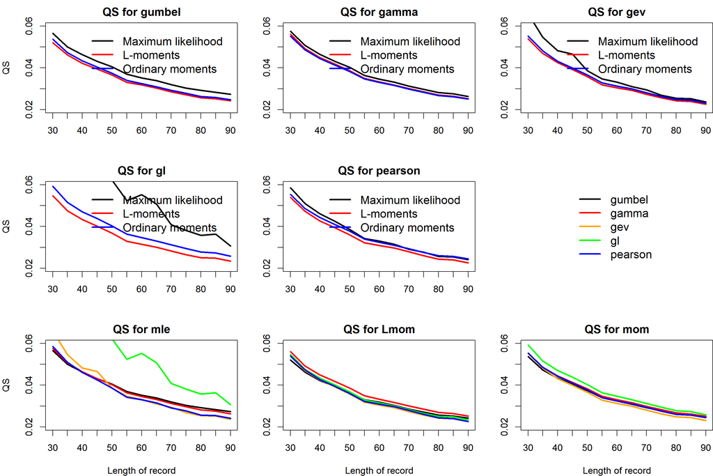

[1] “QS” [1] 2 [1] 19 28 29 31 32 60 62 63 66 67 71 73 74 75 76 80 81 [18] 82 84 86 91 92 93 96 97 98 101 102 103 104 107 108 109 110 [35] 112 123 125 126 127 128 130 133 136 138 139 140 141 142 148 157 163 [52] 182 197 199 201 204 216 220 226 227 268 274 275 276 277 279 283 291 [69] 300 302 [1] “done printint”

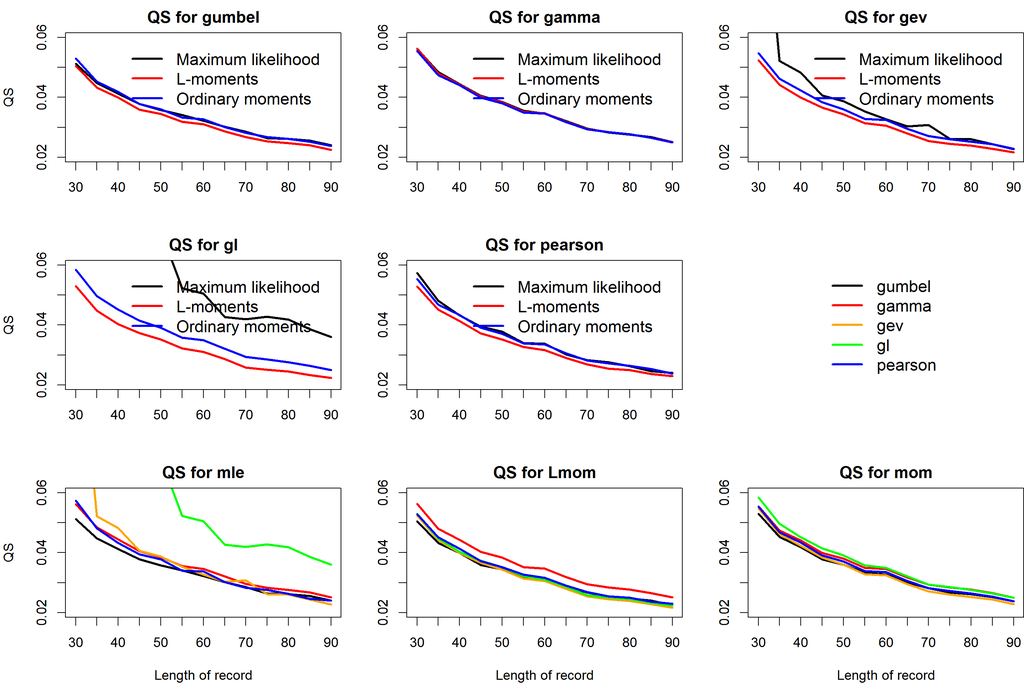

[1] “QS” [1] 2 [1] 3 33 38 51 57 68 70 77 78 79 83 85 87 88 90 94 95 [18] 99 106 111 114 117 129 131 132 134 135 137 145 146 147 149 151 156 [35] 172 176 181 183 187 192 194 195 203 205 215 217 218 219 221 222 225 [52] 228 233 253 254 258 259 263 264 269 270 271 273 278 282 292 293 298 [69] 303 304 305 306 [1] “done printint”

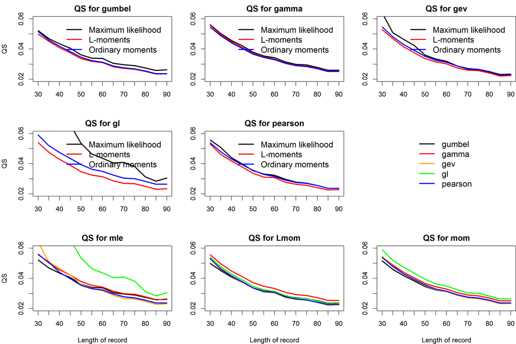

## BS

[1] “BS” [1] 2 [1] 1 2 4 5 6 7 8 9 10 11 12 13 14 15 16 17 18 [18] 20 21 22 23 24 25 26 27 30 34 35 36 37 39 40 41 42 [35] 43 44 45 46 47 48 49 50 52 53 54 55 56 58 59 61 64 [52] 65 69 72 89 100 105 113 115 116 118 119 120 121 122 124 143 144 [69] 150 152 153 154 155 158 159 160 161 162 164 165 166 167 168 169 170 [86] 171 173 174 175 177 178 179 180 185 186 188 189 190 191 196 198 200 [103] 202 207 208 209 211 212 213 214 223 224 229 230 231 234 235 236 237 [120] 238 239 240 241 242 243 244 245 246 247 249 251 252 255 256 257 260 [137] 261 262 272 280 281 285 287 288 289 290 295 [1] “done printint”

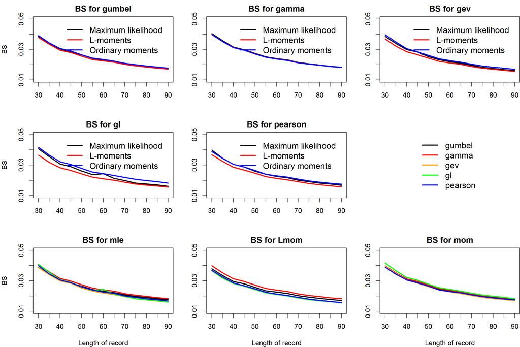

[1] “BS” [1] 2 [1] 19 28 29 31 32 60 62 63 66 67 71 73 74 75 76 80 81 [18] 82 84 86 91 92 93 96 97 98 101 102 103 104 107 108 109 110 [35] 112 123 125 126 127 128 130 133 136 138 139 140 141 142 148 157 163 [52] 182 197 199 201 204 216 220 226 227 268 274 275 276 277 279 283 291 [69] 300 302 [1] “done printint”

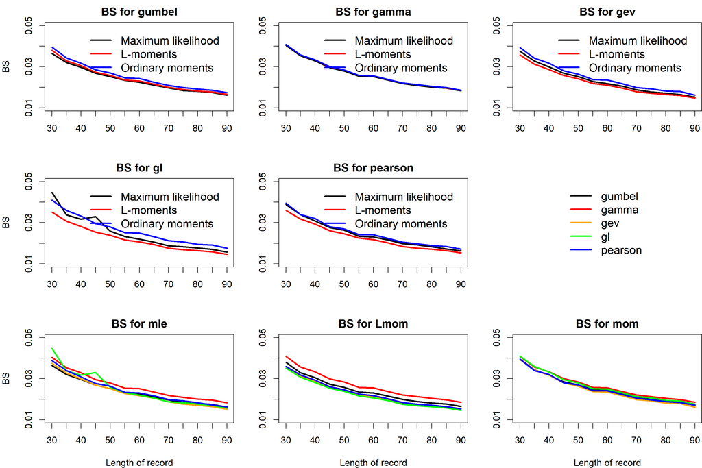

[1] “BS” [1] 2 [1] 3 33 38 51 57 68 70 77 78 79 83 85 87 88 90 94 95 [18] 99 106 111 114 117 129 131 132 134 135 137 145 146 147 149 151 156 [35] 172 176 181 183 187 192 194 195 203 205 215 217 218 219 221 222 225 [52] 228 233 253 254 258 259 263 264 269 270 271 273 278 282 292 293 298 [69] 303 304 305 306 [1] “done printint”

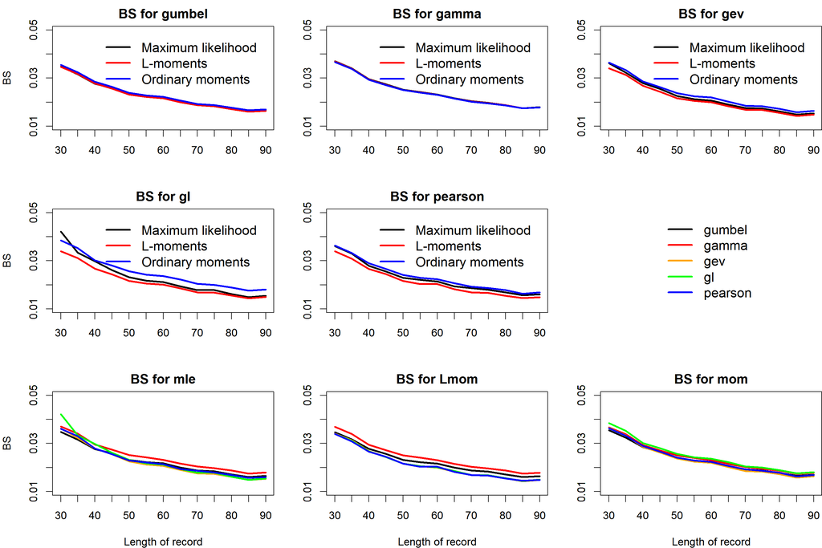

## Return levels

#### RL 10y

[1] “r.levels” [1] 10 [1] 1 2 4 5 6 7 8 9 10 11 12 13 14 15 16 17 18 [18] 20 21 22 23 24 25 26 27 30 34 35 36 37 39 40 41 42 [35] 43 44 45 46 47 48 49 50 52 53 54 55 56 58 59 61 64 [52] 65 69 72 89 100 105 113 115 116 118 119 120 121 122 124 143 144 [69] 150 152 153 154 155 158 159 160 161 162 164 165 166 167 168 169 170 [86] 171 173 174 175 177 178 179 180 185 186 188 189 190 191 196 198 200 [103] 202 207 208 209 211 212 213 214 223 224 229 230 231 234 235 236 237 [120] 238 239 240 241 242 243 244 245 246 247 249 251 252 255 256 257 260 [137] 261 262 272 280 281 285 287 288 289 290 295 [1] “done printint”

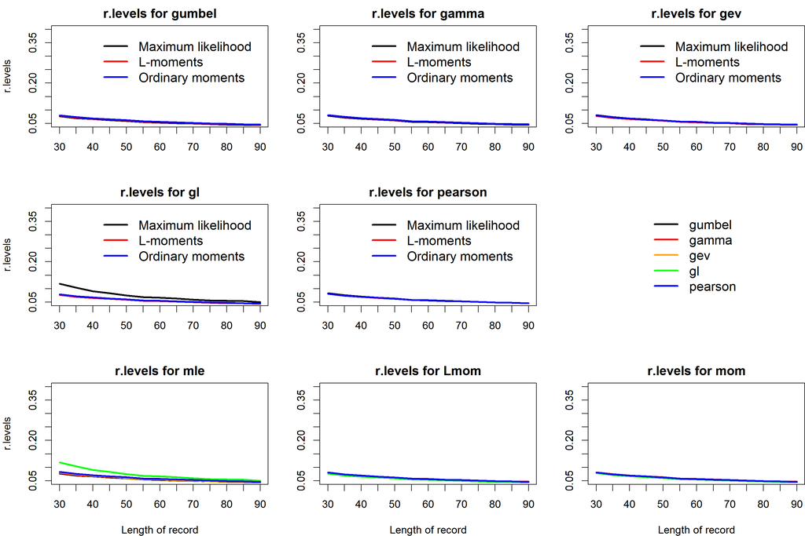

[1] “r.levels” [1] 10 [1] 19 28 29 31 32 60 62 63 66 67 71 73 74 75 76 80 81 [18] 82 84 86 91 92 93 96 97 98 101 102 103 104 107 108 109 110 [35] 112 123 125 126 127 128 130 133 136 138 139 140 141 142 148 157 163 [52] 182 197 199 201 204 216 220 226 227 268 274 275 276 277 279 283 291 [69] 300 302 [1] “done printint”

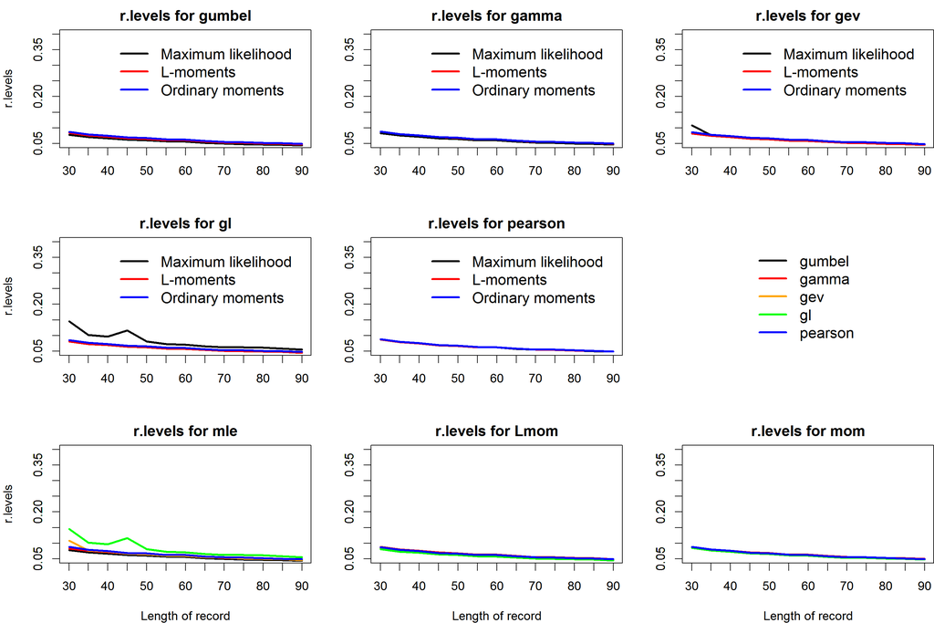

[1] “r.levels” [1] 10 [1] 3 33 38 51 57 68 70 77 78 79 83 85 87 88 90 94 95 [18] 99 106 111 114 117 129 131 132 134 135 137 145 146 147 149 151 156 [35] 172 176 181 183 187 192 194 195 203 205 215 217 218 219 221 222 225 [52] 228 233 253 254 258 259 263 264 269 270 271 273 278 282 292 293 298 [69] 303 304 305 306 [1] “done printint”

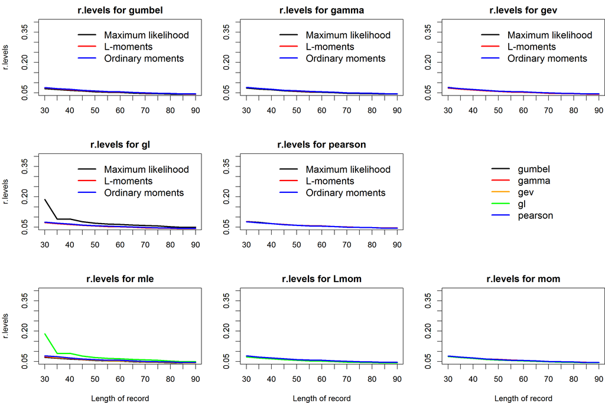

#### RL 100y

[1] “r.levels” [1] 100 [1] 1 2 4 5 6 7 8 9 10 11 12 13 14 15 16 17 18 [18] 20 21 22 23 24 25 26 27 30 34 35 36 37 39 40 41 42 [35] 43 44 45 46 47 48 49 50 52 53 54 55 56 58 59 61 64 [52] 65 69 72 89 100 105 113 115 116 118 119 120 121 122 124 143 144 [69] 150 152 153 154 155 158 159 160 161 162 164 165 166 167 168 169 170 [86] 171 173 174 175 177 178 179 180 185 186 188 189 190 191 196 198 200 [103] 202 207 208 209 211 212 213 214 223 224 229 230 231 234 235 236 237 [120] 238 239 240 241 242 243 244 245 246 247 249 251 252 255 256 257 260 [137] 261 262 272 280 281 285 287 288 289 290 295 [1] “done printint”

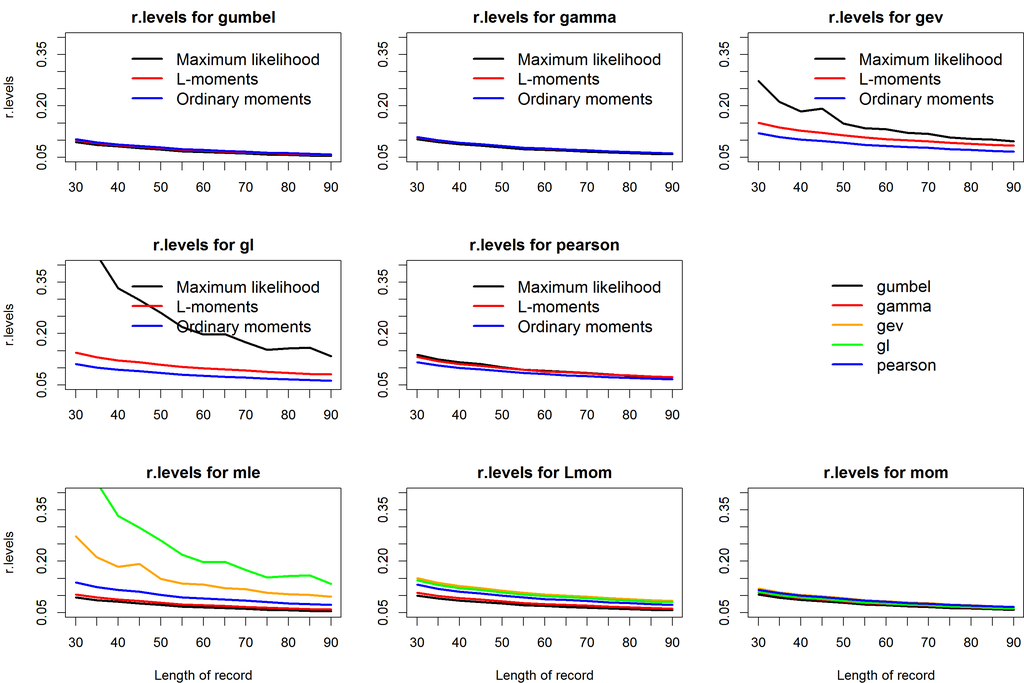

[1] “r.levels” [1] 100 [1] 19 28 29 31 32 60 62 63 66 67 71 73 74 75 76 80 81 [18] 82 84 86 91 92 93 96 97 98 101 102 103 104 107 108 109 110 [35] 112 123 125 126 127 128 130 133 136 138 139 140 141 142 148 157 163 [52] 182 197 199 201 204 216 220 226 227 268 274 275 276 277 279 283 291 [69] 300 302 [1] “done printint”

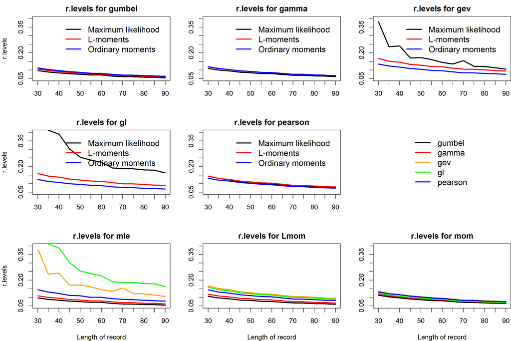

[1] “r.levels” [1] 100 [1] 3 33 38 51 57 68 70 77 78 79 83 85 87 88 90 94 95 [18] 99 106 111 114 117 129 131 132 134 135 137 145 146 147 149 151 156 [35] 172 176 181 183 187 192 194 195 203 205 215 217 218 219 221 222 225 [52] 228 233 253 254 258 259 263 264 269 270 271 273 278 282 292 293 298 [69] 303 304 305 306 [1] “done printint”

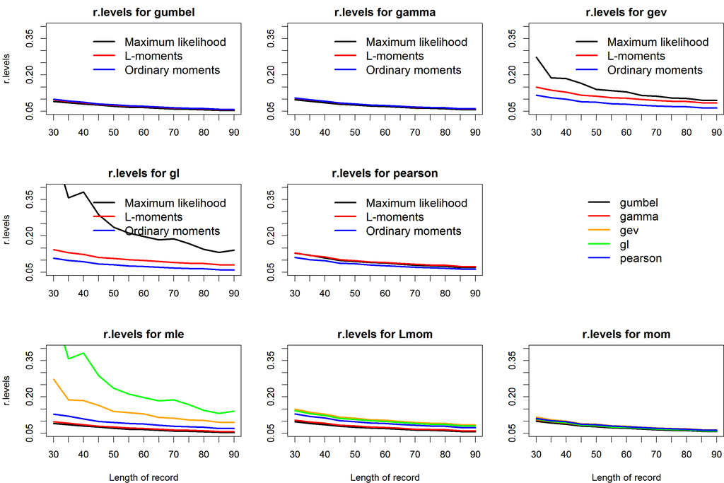

#### RL 200y

[1] “r.levels” [1] 200 [1] 1 2 4 5 6 7 8 9 10 11 12 13 14 15 16 17 18 [18] 20 21 22 23 24 25 26 27 30 34 35 36 37 39 40 41 42 [35] 43 44 45 46 47 48 49 50 52 53 54 55 56 58 59 61 64 [52] 65 69 72 89 100 105 113 115 116 118 119 120 121 122 124 143 144 [69] 150 152 153 154 155 158 159 160 161 162 164 165 166 167 168 169 170 [86] 171 173 174 175 177 178 179 180 185 186 188 189 190 191 196 198 200 [103] 202 207 208 209 211 212 213 214 223 224 229 230 231 234 235 236 237 [120] 238 239 240 241 242 243 244 245 246 247 249 251 252 255 256 257 260 [137] 261 262 272 280 281 285 287 288 289 290 295 [1] “done printint”

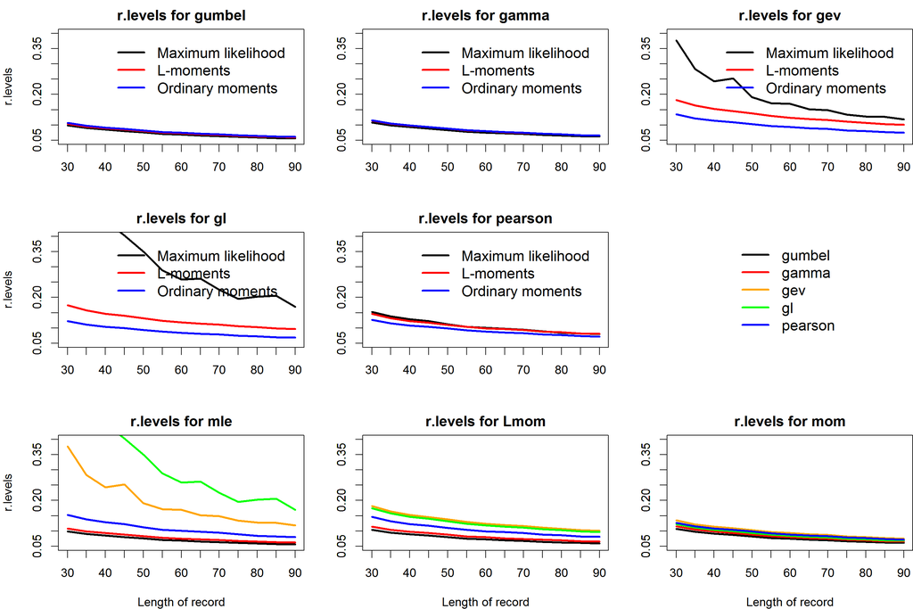

[1] “r.levels” [1] 200 [1] 19 28 29 31 32 60 62 63 66 67 71 73 74 75 76 80 81 [18] 82 84 86 91 92 93 96 97 98 101 102 103 104 107 108 109 110 [35] 112 123 125 126 127 128 130 133 136 138 139 140 141 142 148 157 163 [52] 182 197 199 201 204 216 220 226 227 268 274 275 276 277 279 283 291 [69] 300 302 [1] “done printint”

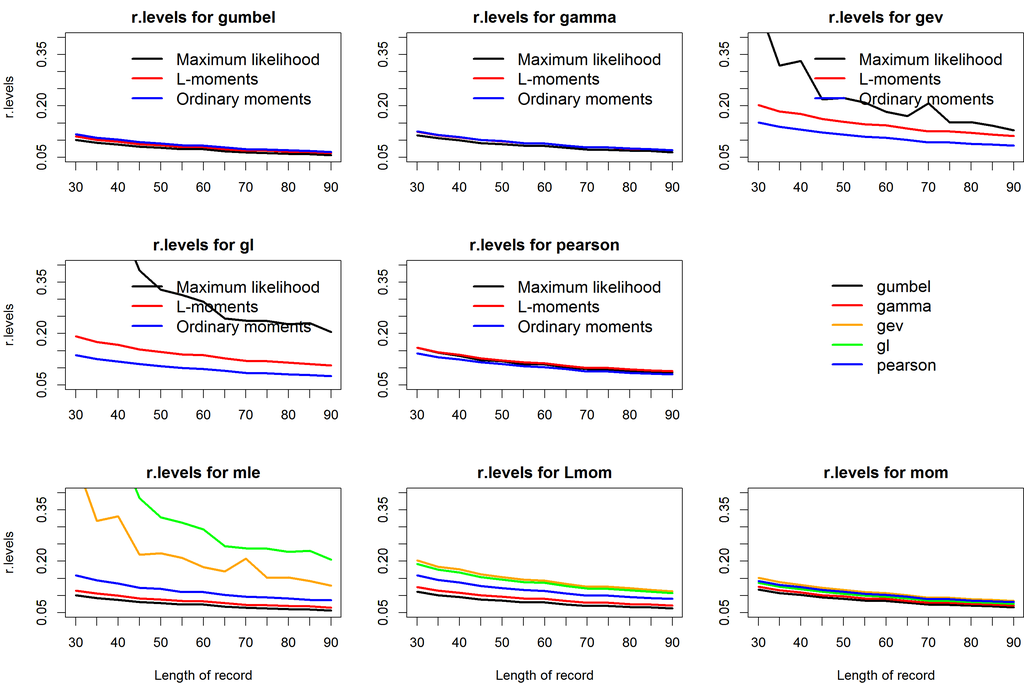

[1] “r.levels” [1] 200 [1] 3 33 38 51 57 68 70 77 78 79 83 85 87 88 90 94 95 [18] 99 106 111 114 117 129 131 132 134 135 137 145 146 147 149 151 156 [35] 172 176 181 183 187 192 194 195 203 205 215 217 218 219 221 222 225 [52] 228 233 253 254 258 259 263 264 269 270 271 273 278 282 292 293 298 [69] 303 304 305 306 [1] “done printint”

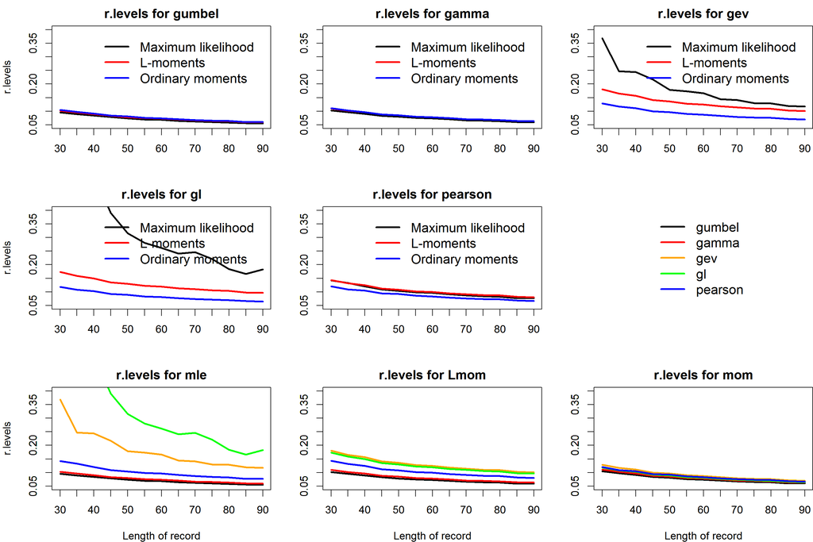

## KS

[1] 1 2 4 5 6 7 8 9 10 11 12 13 14 15 16 17 18 [18] 20 21 22 23 24 25 26 27 30 34 35 36 37 39 40 41 42 [35] 43 44 45 46 47 48 49 50 52 53 54 55 56 58 59 61 64 [52] 65 69 72 89 100 105 113 115 116 118 119 120 121 122 124 143 144 [69] 150 152 153 154 155 158 159 160 161 162 164 165 166 167 168 169 170 [86] 171 173 174 175 177 178 179 180 185 186 188 189 190 191 196 198 200 [103] 202 207 208 209 211 212 213 214 223 224 229 230 231 234 235 236 237 [120] 238 239 240 241 242 243 244 245 246 247 249 251 252 255 256 257 260 [137] 261 262 272 280 281 285 287 288 289 290 295 [1] “entered the plotting function” [1] 30 [1] 150

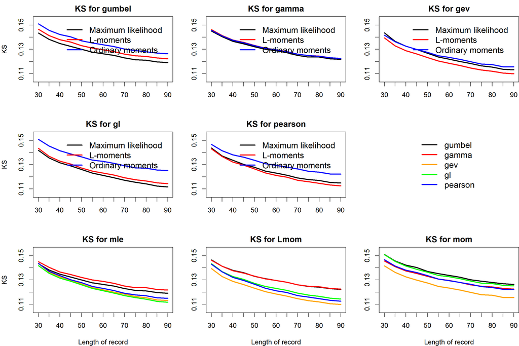

[1] 19 28 29 31 32 60 62 63 66 67 71 73 74 75 76 80 81 [18] 82 84 86 91 92 93 96 97 98 101 102 103 104 107 108 109 110 [35] 112 123 125 126 127 128 130 133 136 138 139 140 141 142 148 157 163 [52] 182 197 199 201 204 216 220 226 227 268 274 275 276 277 279 283 291 [69] 300 302 [1] “entered the plotting function” [1] 30 [1] 150

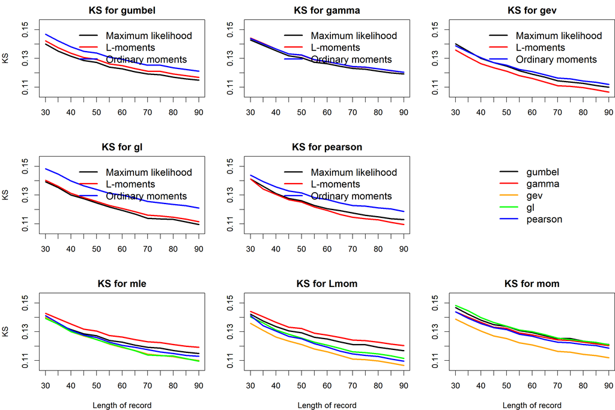

[1] 3 33 38 51 57 68 70 77 78 79 83 85 87 88 90 94 95 [18] 99 106 111 114 117 129 131 132 134 135 137 145 146 147 149 151 156 [35] 172 176 181 183 187 192 194 195 203 205 215 217 218 219 221 222 225 [52] 228 233 253 254 258 259 263 264 269 270 271 273 278 282 292 293 298 [69] 303 304 305 306 [1] “entered the plotting function” [1] 30 [1] 150

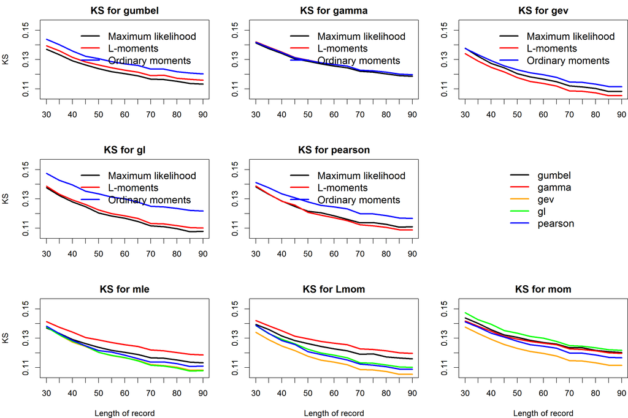

## AD

[1] 1 2 4 5 6 7 8 9 10 11 12 13 14 15 16 17 18 [18] 20 21 22 23 24 25 26 27 30 34 35 36 37 39 40 41 42 [35] 43 44 45 46 47 48 49 50 52 53 54 55 56 58 59 61 64 [52] 65 69 72 89 100 105 113 115 116 118 119 120 121 122 124 143 144 [69] 150 152 153 154 155 158 159 160 161 162 164 165 166 167 168 169 170 [86] 171 173 174 175 177 178 179 180 185 186 188 189 190 191 196 198 200 [103] 202 207 208 209 211 212 213 214 223 224 229 230 231 234 235 236 237 [120] 238 239 240 241 242 243 244 245 246 247 249 251 252 255 256 257 260 [137] 261 262 272 280 281 285 287 288 289 290 295 [1] “entered the plotting function” [1] 30 [1] 150

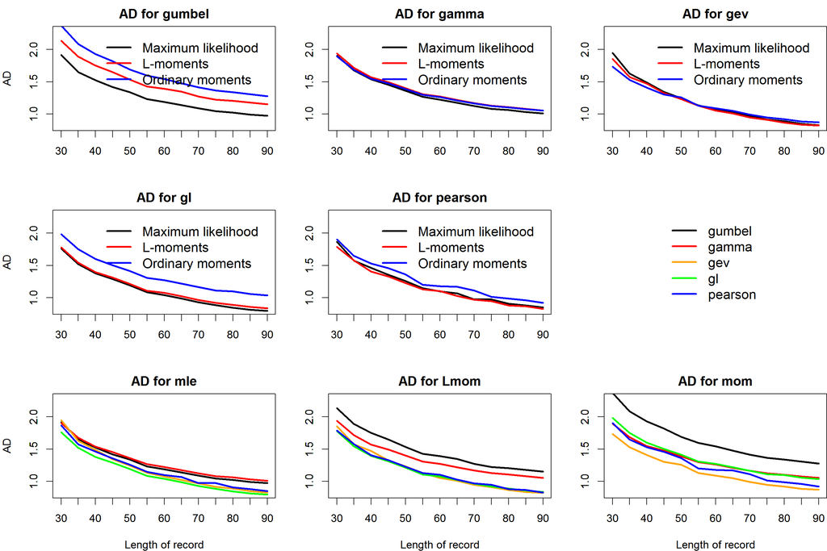

[1] 19 28 29 31 32 60 62 63 66 67 71 73 74 75 76 80 81 [18] 82 84 86 91 92 93 96 97 98 101 102 103 104 107 108 109 110 [35] 112 123 125 126 127 128 130 133 136 138 139 140 141 142 148 157 163 [52] 182 197 199 201 204 216 220 226 227 268 274 275 276 277 279 283 291 [69] 300 302 [1] “entered the plotting function” [1] 30 [1] 150

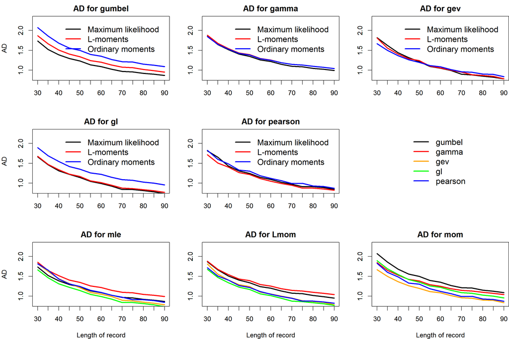

[1] 3 33 38 51 57 68 70 77 78 79 83 85 87 88 90 94 95 [18] 99 106 111 114 117 129 131 132 134 135 137 145 146 147 149 151 156 [35] 172 176 181 183 187 192 194 195 203 205 215 217 218 219 221 222 225 [52] 228 233 253 254 258 259 263 264 269 270 271 273 278 282 292 293 298 [69] 303 304 305 306 [1] “entered the plotting function” [1] 30 [1] 150

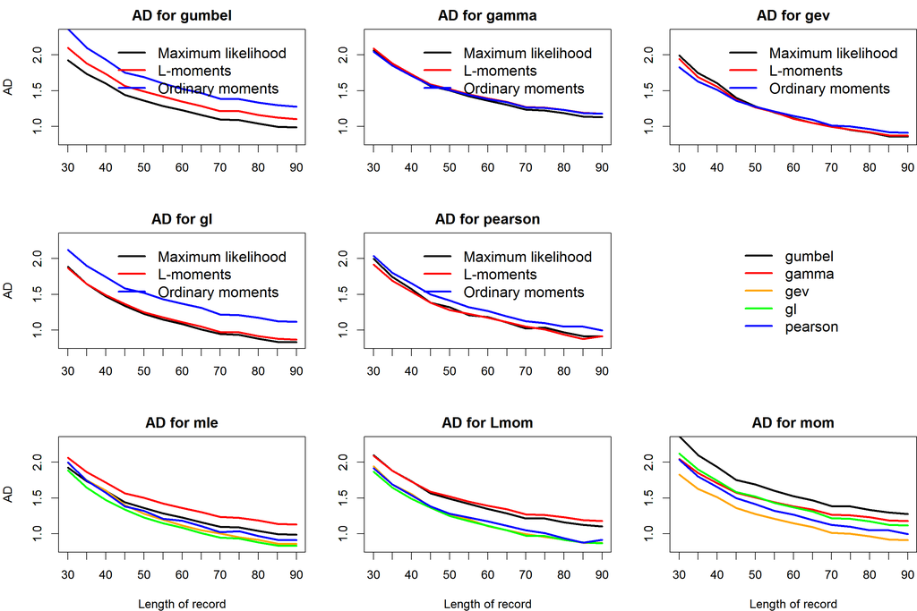